# day1

## Introduction: Building Molecules

This exercise introduces you to the basic workflow of computational chemistry using the Atomic Simulation Environment (ASE) and NGLView within a Jupyter Notebook. Your goal is to build molecules, manage their data (saving them in the XYZ format), and visualize them.

### Exersices:

1. Builing molecules using ASE
2. Create a scientific plot

### Exercise 1: Building molecules

In the following, import all necessary packages and libraries. If a package is not installed, use 'pip install package'

ASE is essential for handling atomic structures, and NGLView allows for interactive 3D visualization.

```python
import numpy as np
from ase import Atoms
from ase.build import molecule
from ase.data.pubchem import pubchem_atoms_search
from ase.visualize import view
from ase.io import write
import nglview as nv
```

In this exersice, you will learn how to load molecular structures using the ASE package, save them as xyz files, and visualize them interactively using nglview and ase view.

#### Example with water:

create a water molecule using ASE

```python
# load molecular structure using the molecule function from ASE
water = molecule("H2O")
```

Print information about the system, such as the chemical symbols, chemical formula, positions of the atoms, atomic numbers, distances between the atoms H and O, and the H-O-H angle. All this is possible using functions implemented in ASE. You can use the documentation to find the functions: https://ase-lib.org/index.html

Hint: all the functions start with get_ ...

```python
# print chemical formula
print(water.get_chemical_formula())

# print chemical symbols
print(water.get_chemical_symbols())

# print positions of the atoms
pos = np.array(water.get_positions())
print(pos)

# print atomic numbers
print(water.get_atomic_numbers())

# print distances between the atoms H and O
print(np.linalg.norm(pos[0] - pos[1]))

# print the H-O-H angle
print(water.get_angle(1, 0, 2))
```

```
H2O
['O', 'H', 'H']
[[ 0.        0.        0.119262]
 [ 0.        0.763239 -0.477047]
 [ 0.       -0.763239 -0.477047]]
[8 1 1]
0.9685650182625842
103.99987509868838
```

Save the molecule as an xyz file by writing it to a file called "water.xyz".

```python
# save the molecular structure as xyz file
write("water.xyz", water)
```

Visualize the molecule to make sure that it looks correct. You can use the nglview package for visualization. Use the function show_ase() from the package nglview which was imported as nv.

```python
# visualize the molecule
view = nv.show_ase(water)
view
```

```
NGLWidget()
```

You can also save the picture of the molecule by using the function download_image() from the nglview package. Save the image as filename = "water.png".

```python
# save the picture of the molecule as png file
view.download_image(filename="water.png")
```

Create the objects for the molecules isobutane and acetone and visualize them.

```python
# Isobutane
isobutane = molecule("isobutane")
iso_view = nv.show_ase(isobutane)
iso_view
```

```
NGLWidget()
```

```python
# Acetone
acetone = molecule("CH3COCH3")
ace_view = nv.show_ase(acetone)
ace_view

#
```

```
NGLWidget()
```

```python
# Calculate structural parameters for acetone
import numpy as np

# Get atomic positions and symbols
positions = acetone.get_positions()
symbols = acetone.get_chemical_symbols()

print("Atom indices and symbols:")
for i, sym in enumerate(symbols):
    print(f"  Atom {i}: {sym} at position ({positions[i][0]:.3f}, {positions[i][1]:.3f}, {positions[i][2]:.3f}) Å")

# Function to calculate bond length
def bond_length(pos1, pos2):
    return np.linalg.norm(pos1 - pos2)

# Function to calculate bond angle (in degrees)
def bond_angle(pos1, pos2, pos3):
    """Calculate angle at pos2 formed by pos1-pos2-pos3"""
    v1 = pos1 - pos2
    v2 = pos3 - pos2
    cos_angle = np.dot(v1, v2) / (np.linalg.norm(v1) * np.linalg.norm(v2))
    return np.degrees(np.arccos(np.clip(cos_angle, -1.0, 1.0)))

# Function to calculate dihedral angle (in degrees)
def dihedral_angle(pos1, pos2, pos3, pos4):
    """Calculate dihedral angle for four atoms"""
    b1 = pos2 - pos1
    b2 = pos3 - pos2
    b3 = pos4 - pos3

    n1 = np.cross(b1, b2)
    n2 = np.cross(b2, b3)

    m1 = np.cross(n1, b2 / np.linalg.norm(b2))

    x = np.dot(n1, n2)
    y = np.dot(m1, n2)

    return np.degrees(np.arctan2(y, x))
```

```
Atom indices and symbols:
  Atom 0: O at position (0.000, 0.000, 1.406) Å
  Atom 1: C at position (0.000, 0.000, 0.179) Å
  Atom 2: C at position (0.000, 1.285, -0.616) Å
  Atom 3: C at position (0.000, -1.285, -0.616) Å
  Atom 4: H at position (0.000, 2.135, 0.067) Å
  Atom 5: H at position (0.000, -2.135, 0.067) Å
  Atom 6: H at position (-0.881, 1.332, -1.264) Å
  Atom 7: H at position (0.881, 1.332, -1.264) Å
  Atom 8: H at position (0.881, -1.332, -1.264) Å
  Atom 9: H at position (-0.881, -1.332, -1.264) Å
```

```python
# Interesting bond lengths (No C-H length)

# Find carbon and oxygen atoms
carbon_indices = [i for i, sym in enumerate(symbols) if sym == 'C']
oxygen_indices = [i for i, sym in enumerate(symbols) if sym == 'O']

# C=O bond (carbonyl)
if len(oxygen_indices) > 0:
    # Find which carbon is closest to oxygen (carbonyl carbon)
    distances_to_O = [(i, bond_length(positions[i], positions[oxygen_indices[0]]))
                      for i in carbon_indices]
    carbonyl_C = min(distances_to_O, key=lambda x: x[1])[0]
    co_bond = bond_length(positions[carbonyl_C], positions[oxygen_indices[0]])
    print(f"C=O bond length (carbonyl): {co_bond:.3f} Å")

    # C-C bonds
    other_carbons = [c for c in carbon_indices if c != carbonyl_C]
    for c in other_carbons:
        cc_bond = bond_length(positions[carbonyl_C], positions[c])
        print(f"C-C bond length (C{carbonyl_C}-C{c}): {cc_bond:.3f} Å")
```

```
C=O bond length (carbonyl): 1.227 Å
C-C bond length (C1-C2): 1.512 Å
C-C bond length (C1-C3): 1.512 Å
```

```python
# Calculate bond angles in acetone

# C-C=O angle (at carbonyl carbon)
if len(oxygen_indices) > 0 and len(other_carbons) >= 1:
    angle_CCO = bond_angle(positions[other_carbons[0]],
                           positions[carbonyl_C],
                           positions[oxygen_indices[0]])
    print(f"C-C=O angle: {angle_CCO:.2f}°")

    # C-C-C angle (at carbonyl carbon) - between the two methyl groups
    if len(other_carbons) >= 2:
        angle_CCC = bond_angle(positions[other_carbons[0]],
                               positions[carbonyl_C],
                               positions[other_carbons[1]])
        print(f"C-C-C angle (between methyl groups): {angle_CCC:.2f}°")

    # H-C-H angles in methyl groups
    for c in other_carbons[:1]:  # Just show one methyl group as example
        h_near_c = [h for h in h_indices if bond_length(positions[c], positions[h]) < 1.2]
        if len(h_near_c) >= 2:
            angle_HCH = bond_angle(positions[h_near_c[0]],
                                   positions[c],
                                   positions[h_near_c[1]])
            print(f"H-C-H angle in methyl group: {angle_HCH:.2f}°")

    # C-C-H angle (methyl group)
    for c in other_carbons[:1]:
        h_near_c = [h for h in h_indices if bond_length(positions[c], positions[h]) < 1.2]
        if h_near_c:
            angle_CCH = bond_angle(positions[carbonyl_C],
                                   positions[c],
                                   positions[h_near_c[0]])
            print(f"C-C-H angle in methyl group: {angle_CCH:.2f}°")
```

```
C-C=O angle: 121.75°
C-C-C angle (between methyl groups): 116.51°
H-C-H angle in methyl group: 109.75°
C-C-H angle in methyl group: 109.46°
```

```python
# Calculate dihedral angles in acetone

# C-C-C=O dihedral
dihedral_CCCO = dihedral_angle(positions[other_carbons[0]], positions[other_carbons[1]], positions[carbonyl_C], positions[oxygen_indices[0]])
print(f"C-C-C=O dihedral angle: {dihedral_CCCO:.2f}°")
```

```
C-C-C=O dihedral angle: 180.00°
```

Some molecules cannot be created using the molecule() function from ase for example for the molecules benzophenone, maleicacid and 2,4,6-trinitrophenol. Instead, there is a function from ase.data.pubchem which is called pubchem_atoms_search(). Using this, you can generate the structures and visualize them.

```python
# Benzophenone
benzo = pubchem_atoms_search("Benzophenone")
benzo_view = nv.show_ase(benzo)
benzo_view
```

```
NGLWidget()
```

```python
# Maleicacid
male = pubchem_atoms_search("Maleicacid")
male_view = nv.show_ase(male)
male_view
```

```
NGLWidget()
```

```python
# 2,4,6-trinitrophenol
trini = pubchem_atoms_search("2,4,6-trinitrophenol")
trini_view = nv.show_ase(trini)
trini_view
```

```
NGLWidget()
```

Some molecules are not available in the data base. Instead, you can enter the positions of the atoms manually. For example, for tetrachloroplatinate, you can use the following coordinates:

x, y and z coordinates in Angstroms:

Pt 0.0 0.0 0.0

Cl 2.3 0.0 0.0

Cl -2.3 0.0 0.0

Cl 0.0 2.3 0.0

Cl 0.0 -2.3 0.0

```python
tetra = Atoms(["Pt", "Cl", "Cl", "Cl", "Cl"], positions=[(0, 0, 0), (2.3, 0, 0), (-2.3, 0, 0), (0, 2.3, 0), (0, -2.3, 0)])
tetra_view = nv.show_ase(tetra)
tetra_view
```

```
NGLWidget()
```

```python
# Download all images
iso_view.download_image("isobutane.png")
ace_view.download_image("acetone.png")
benzo_view.download_image("benzophenone.png")
male_view.download_image("maleicacid.png")
trini_view.download_image("picricacid.png")
tetra_view.download_image("tetrachloroplatinate.png")
```

### Exercise 2: Creating a scientific plot

Load the provided datafile /software/uebungen/templates/Aufgabe1/morse-potential.dat and create a plot the corresponding data.

First, import the packages numpy and matplotlib.pyplot.

```python
import numpy as np
import matplotlib.pyplot as plt
```

Then, load the data using the loadtxt() function from numpy. The data file contains two columns: the first column is the distance between two atoms and the second column is the potential energy.

```python
# load data
data =  np.loadtxt("morse-potential.dat")
```

Finally, create a plot of the potential energy as a function of atom distance using matplotlib. Make sure to label your axes properly. The x-axis should be labeled "Distance (Å)" and the y-axis should be labeled "Potential Energy (eV)". You can also add a title to your plot, such as "Morse Potential".

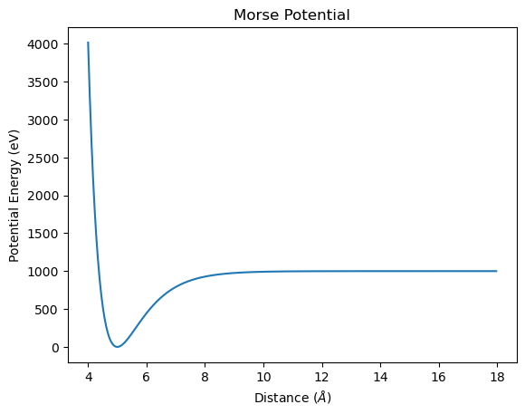

```python
# create plot
plt.plot(data.T[0], data.T[1])
plt.xlabel(r"Distance ($\AA$)")
plt.ylabel("Potential Energy (eV)")
plt.title("Morse Potential")
plt.show()
```